# Predicting Medical Charges: A Comparative Analysis of Linear and Robust Linear Regression Models

Peerapan Nantang

# Abstract

This analysis uses linear and robust regression models to predict healthcare charges based on patient factors. The robust model is preferable due to its resistance to outliers. Key drivers of higher costs are smoking, high BMI, more children, and Northeast region. To reduce spending, the report recommends focusing on smoking cessation, healthy BMI, family planning, and analyzing regional cost differences. Targeting modifiable health risks through public health initiatives could significantly curb rising healthcare expenditures.

# Introduction

Medical costs billed by health insurance are a major concern for individuals and policymakers alike. Understanding the factors that contribute to these costs is essential for developing effective strategies to control them.

The dataframe used in this report contains information on the following variables:

- Age
- Sex
- BMI
- Children
- Smoker
- Region
- Charges

The objective of this report is to understand drivers of healthcare costs and provide recommendations to reduce spending.

## Loading Libraries

```r
library(tidyverse)
library(car)
library(readxl)
library(dlookr)
library(flextable)
library(performance)
library(ggstatsplot)
library(moments)
library(glmulti)
library(caret)
library(glmnet)
library(naniar)
library(effectsize)
```

## Loading and Previewing a Data Frame

```r
df <- read_excel("insurance_na.xlsx")

glimpse(df)
```

```
## Rows: 1,347
## Columns: 7
## $ age      <dbl> 19, 18, 28, 19, 33, 32, NA, 46, 37, 37, 60, 25, 62, 19, 23, 5…
## $ sex      <chr> "female", "male", "male", "female", "male", "male", "female",…
## $ bmi      <dbl> 27.900, 33.770, 33.000, 27.900, 22.705, 28.880, 25.740, NA, 2…
## $ children <dbl> 0, 1, 3, 0, 0, 0, 0, 1, 3, 2, 0, 0, 0, 0, 0, 0, 0, 0, 1, 1, 0…
## $ smoker   <chr> "yes", "no", "no", "yes", "no", "no", "no", "no", "no", "no",…
## $ region   <chr> "southwest", "southeast", "southeast", "southwest", "northwes…
## $ charges  <dbl> 16884.924, 1725.552, 4449.462, 16884.924, 21984.471, 3866.855…
```

Here is a description of each variable in the dataframe:

- **Age**: The age of the individuals in the dataset.
- **Sex**: The gender of the individuals. It includes categories such as ‘male’ and ‘female’.
- **BMI**: The Body Mass Index of the individuals. Body Mass Index is a measure used to determine whether a person has a healthy body weight for their height.
- **Children**: The number of children each individual has.
- **Smoker**: Whether the individual is a smoker or not. It includes categories such as ‘yes’ and ‘no’.
- **Region**: The region where the individuals live. It includes categories such as ‘southwest’, ‘southeast’, ‘northwest’, and ‘northeast’.
- **Charges**: The individual medical costs billed by health insurance

## Removing Duplicate Rows

```r
remove_duplicates <- function(df) {
  # Find duplicated rows
  dup_rows <- duplicated(df) | duplicated(df, fromLast = TRUE)

  # If there are no duplicated rows, return the original data frame
  if (!any(dup_rows)) {
    cat("No duplicates found\n")
    return(df)
  }

  # Find the row indices of the duplicated rows
  dup_indices <- which(dup_rows)

  # Group the duplicated rows by their values
  groups <- split(dup_indices, apply(df[dup_rows, ], 1, paste, collapse = ""))

  # Print a message to inform the user that duplicate rows were found
  cat("Duplicate rows found at indices:\n")

  # For each group of duplicated rows
  for (group in groups) {
    # Sort the row indices in ascending order
    group <- sort(group)

    # Print the row indices of the duplicates
    cat(paste(group, collapse = ", "), "\n")

    # Keep the row with the lowest index and remove the rest
    df <- df[!duplicated(df), ]
  }

  return(df)
}
```

```r
df <- remove_duplicates(df)
```

```
## Duplicate rows found at indices:
## 1, 4, 14, 18
## 112, 455
## 201, 588
## 555, 722, 898, 1233
## 22, 66, 88
```

The `remove_duplicates` function identifies and removes duplicate rows from a data frame. It first checks for any duplicated rows in the input data frame. If duplicates exist, it groups these duplicates and prints their indices. The function then retains only the first occurrence from each group of duplicates and removes the rest.

In this case, duplicates were found at indices 1, 4, 14, 18; 112, 455; 201, 588; 555, 722, 898, 1233; and 22, 66, 88. The function successfully eliminated these duplicates, returning a data frame `df` containing only unique rows.

## General Diagnosis

```r
diagnose(df) %>%
  flextable()
```

| variables | types | missing_count | missing_percent | unique_count | unique_rate |
| --- | --- | --- | --- | --- | --- |
| age | numeric | 34 | 2.543007 | 48 | 0.035901272 |
| sex | character | 0 | 0.000000 | 2 | 0.001495886 |
| bmi | numeric | 60 | 4.487659 | 539 | 0.403141361 |
| children | numeric | 0 | 0.000000 | 6 | 0.004487659 |
| smoker | character | 0 | 0.000000 | 2 | 0.001495886 |
| region | character | 0 | 0.000000 | 4 | 0.002991773 |
| charges | numeric | 0 | 0.000000 | 1,337 | 1.000000000 |

## Filtering and Selecting Variables with Low Unique Counts

```r
diagnose(df) %>%
  filter(unique_count <= 10) %>%
  select(variables)
```

```
## # A tibble: 4 × 1
##   variables
##   <chr>
## 1 sex
## 2 children
## 3 smoker
## 4 region
```

The examination of the data reveals four columns that are likely categorical in nature: `sex`, `children`, `smoker`, and `region`. The `sex` column contains two unique values, indicating a binary categorization. The `smoker` column is also binary with two unique values. The `children` column has six distinct categories, while the `region` column has four.

Overall, these four columns with a limited number of discrete values per column suggest categorical data types as opposed to continuous numerical data. Treating them as categorical variables in subsequent analyses would be an appropriate approach for this dataset.

## Finding Unique Values in Selected Columns

```r
lapply(df[ ,c("sex",
             "children",
             "smoker",
             "region")],unique)
```

```
## $sex
## [1] "female" "male"
##
## $children
## [1] 0 1 3 2 5 4
##
## $smoker
## [1] "yes" "no"
##
## $region
## [1] "southwest" "southeast" "northwest" "northeast"
```

From the result, it can be seen that:

- The `sex` column contains two unique values: “female” and “male”. This suggests that the column is a binary categorical variable representing the sex of each individual.
- The `children` column contains 6 unique numeric values ranging from 0 to 5. This indicates that the column is a discrete numerical variable representing the number of children.
- The `smoker` column contains two unique values: “yes” and “no”. This is a binary categorical variable representing smoking status.
- The `region` column has 4 unique values: “southwest”, “southeast”, “northwest”, and “northeast”. This categorical variable indicates the region each individual is from.

Based on these observations, it can be concluded that the `sex`, `children`, `smoker`, and `region` columns will all be converted into factors for analysis. Although the `children` column contains numeric data, it will also be converted to a factor. The reason for this is that the `children` variable will be used as a dummy variable in linear regression analysis. Converting it to a factor will create appropriate dummy coded variables for including `children` as a categorical predictor in the regression model.

## Converting Selected Columns of the Data Frame to Factors

```r
df <- df %>%
  mutate_at(vars(sex, smoker, region, children), factor) %>%
  glimpse()
```

```
## Rows: 1,337
## Columns: 7
## $ age      <dbl> 19, 18, 28, 33, 32, NA, 46, 37, 37, 60, 25, 62, 23, 56, 27, 1…
## $ sex      <fct> female, male, male, male, male, female, female, female, male,…
## $ bmi      <dbl> 27.900, 33.770, 33.000, 22.705, 28.880, 25.740, NA, 27.740, 2…
## $ children <fct> 0, 1, 3, 0, 0, 0, 1, 3, 2, 0, 0, 0, 0, 0, 0, 1, 1, 0, 0, 0, 0…
## $ smoker   <fct> yes, no, no, no, no, no, no, no, no, no, no, yes, no, no, yes…
## $ region   <fct> southwest, southeast, southeast, northwest, northwest, southe…
## $ charges  <dbl> 16884.924, 1725.552, 4449.462, 21984.471, 3866.855, 3756.622,…
```

The `sex`, `smoker`, `region`, and `children` columns in the `df` data frame have been successfully converted to factors.

## General Diagnosis of Numeric Variables

```r
diagnose_numeric(df) %>%
  flextable()
```

| variables | min | Q1 | mean | median | Q3 | max | zero | minus | outlier |
| --- | --- | --- | --- | --- | --- | --- | --- | --- | --- |
| age | 18.000 | 26.000 | 39.21182 | 39.000 | 51.000 | 64.00 | 0 | 0 | 0 |
| bmi | 16.815 | 26.400 | 30.71547 | 30.495 | 34.675 | 53.13 | 0 | 0 | 8 |
| charges | 1,121.874 | 4,746.344 | 13,279.12149 | 9,386.161 | 16,657.717 | 63,770.43 | 0 | 0 | 139 |

```r
find_outliers(df, index = F)
```

```
## [1] "bmi"     "charges"
```

The analysis reveals the existence of outliers in `bmi` and `charges` variables in the dataset.

## General Diagnosis of Categorical Variables

```r
diagnose_category(df) %>%
  flextable()
```

| variables | levels | N | freq | ratio | rank |
| --- | --- | --- | --- | --- | --- |
| sex | male | 1,337 | 675 | 50.486163 | 1 |
| sex | female | 1,337 | 662 | 49.513837 | 2 |
| children | 0 | 1,337 | 573 | 42.857143 | 1 |
| children | 1 | 1,337 | 324 | 24.233358 | 2 |
| children | 2 | 1,337 | 240 | 17.950636 | 3 |
| children | 3 | 1,337 | 157 | 11.742708 | 4 |
| children | 4 | 1,337 | 25 | 1.869858 | 5 |
| children | 5 | 1,337 | 18 | 1.346298 | 6 |
| smoker | no | 1,337 | 1,063 | 79.506358 | 1 |
| smoker | yes | 1,337 | 274 | 20.493642 | 2 |
| region | southeast | 1,337 | 364 | 27.225131 | 1 |
| region | southwest | 1,337 | 325 | 24.308153 | 2 |
| region | northeast | 1,337 | 324 | 24.233358 | 3 |
| region | northwest | 1,337 | 324 | 24.233358 | 3 |

## General Diagnosis of Outlier

```r
diagnose_outlier(df) %>%
  flextable()
```

| variables | outliers_cnt | outliers_ratio | outliers_mean | with_mean | without_mean |
| --- | --- | --- | --- | --- | --- |
| age | 0 | 0.0000000 |  | 39.21182 | 39.21182 |
| bmi | 8 | 0.5983545 | 49.4275 | 30.71547 | 30.59751 |
| charges | 139 | 10.3964099 | 42,103.9472 | 13,279.12149 | 9,934.67176 |

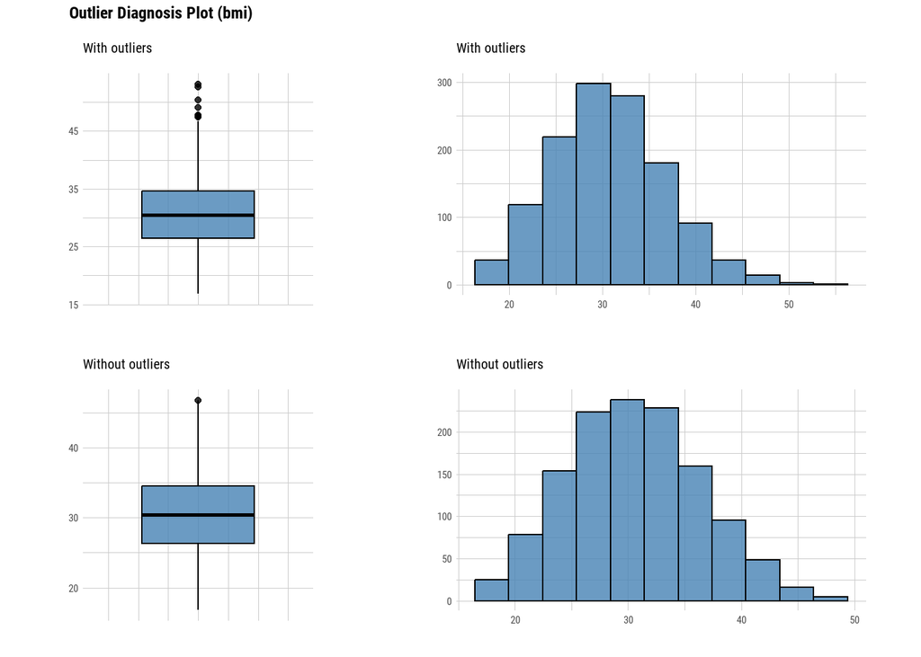

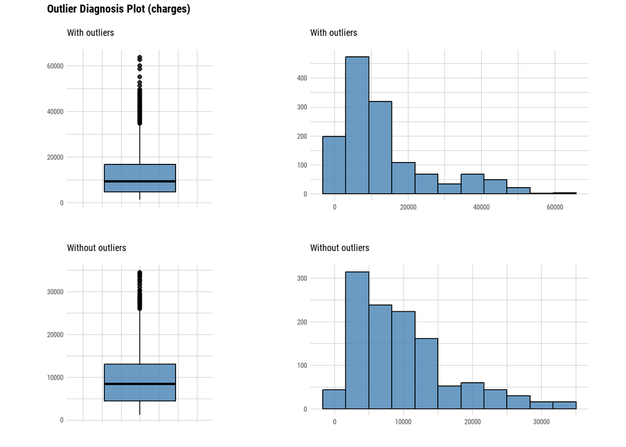

```r
df %>%
  select(find_outliers(df)) %>%
  plot_outlier()
```

The analysis of the effect of outliers on the `bmi` and `charges` variables reveals that the outliers have minimal impact on the mean of `bmi` but potentially distort the mean of `charges`:

For the `bmi` variable, the difference in means between the complete data and the data with 8 outliers removed is small, suggesting the outliers do not substantially influence the central tendency. Given this, imputation or removal of the outlier values appears unnecessary for `bmi`.

However, for `charges`, a noticeable difference exists between the mean of the complete data versus the mean with outliers excluded. This discrepancy indicates the outliers markedly skew the center of the distribution for this variable. Additional steps should be considered to handle these influential points for `charges`.

## Normality Test

```r
normality(df) %>%
  mutate(p_value = round(p_value, 6)) %>%
  flextable()
```

| vars | statistic | p_value | sample |
| --- | --- | --- | --- |
| age | 0.9437301 | 0.000000 | 1,337 |
| bmi | 0.9933574 | 0.000017 | 1,337 |
| charges | 0.8147608 | 0.000000 | 1,337 |

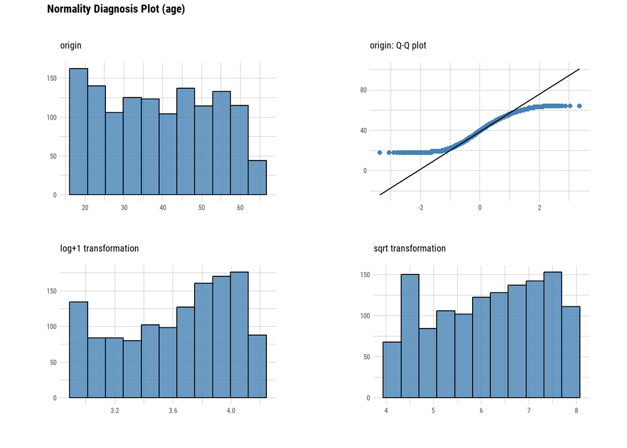

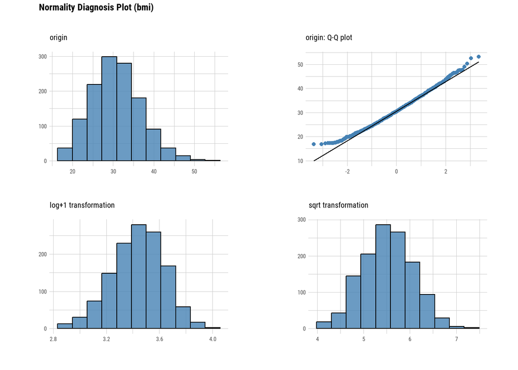

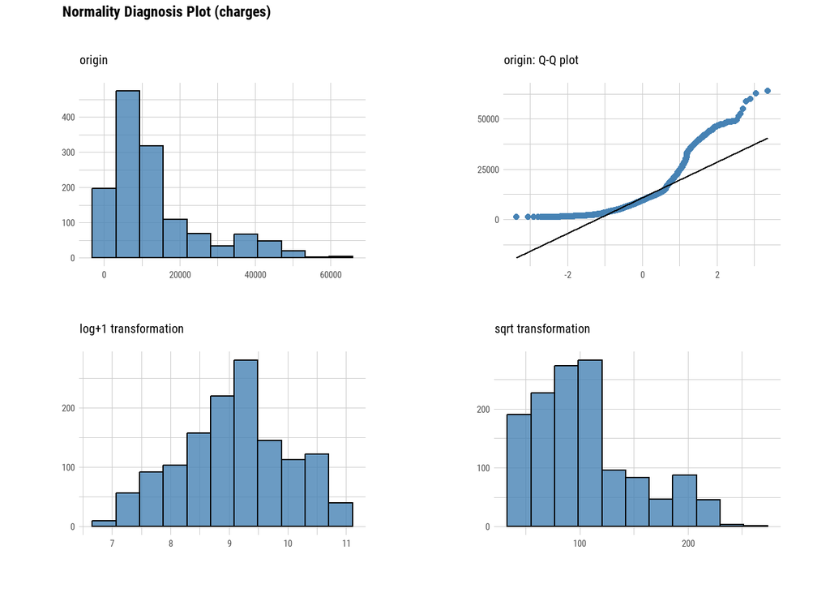

```r
df %>%
  plot_normality(colnames(df), left = "log+1", right = "sqrt")
```

## Skewness Test

```r
df %>%
  select_if(is.numeric) %>%
  lapply(agostino.test)
```

```
## $age
##
##  D'Agostino skewness test
##
## data:  X[[i]]
## skew = 0.051101, z = 0.756841, p-value = 0.4491
## alternative hypothesis: data have a skewness
##
##
## $bmi
##
##  D'Agostino skewness test
##
## data:  X[[i]]
## skew = 0.29524, z = 4.24438, p-value = 2.192e-05
## alternative hypothesis: data have a skewness
##
##
## $charges
##
##  D'Agostino skewness test
##
## data:  X[[i]]
## skew = 1.5137, z = 16.9186, p-value < 2.2e-16
## alternative hypothesis: data have a skewness
```

## Applying Log-Transformation

```r
df <- df %>%
  mutate_at(vars(charges), log) %>%
  glimpse()
```

```
## Rows: 1,337
## Columns: 7
## $ age      <dbl> 19, 18, 28, 33, 32, NA, 46, 37, 37, 60, 25, 62, 23, 56, 27, 1…
## $ sex      <fct> female, male, male, male, male, female, female, female, male,…
## $ bmi      <dbl> 27.900, 33.770, 33.000, 22.705, 28.880, 25.740, NA, 27.740, 2…
## $ children <fct> 0, 1, 3, 0, 0, 0, 1, 3, 2, 0, 0, 0, 0, 0, 0, 1, 1, 0, 0, 0, 0…
## $ smoker   <fct> yes, no, no, no, no, no, no, no, no, no, no, yes, no, no, yes…
## $ region   <fct> southwest, southeast, southeast, northwest, northwest, southe…
## $ charges  <dbl> 9.734176, 7.453302, 8.400538, 9.998092, 8.260197, 8.231275, 9…
```

The `charges` variable in the `df` data frame has been successfully log-transformed.

## Missisng Values

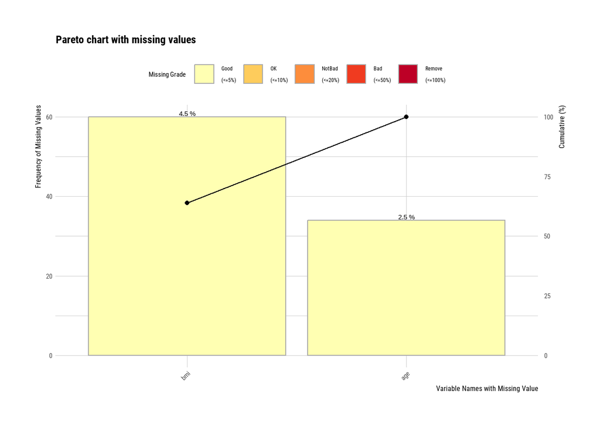

```r
df %>%
  plot_na_pareto(only_na = TRUE)
```

```r
df %>%
  plot_na_pareto(only_na = TRUE, plot = FALSE) %>%
  flextable()
```

| variable | frequencies | ratio | grade | cumulative |
| --- | --- | --- | --- | --- |
| bmi | 60 | 0.04487659 | Good | 63.82979 |
| age | 34 | 0.02543007 | Good | 100.00000 |

### MCAR checking

```r
# Set the significance level
alpha <- 0.05

# Perform Little's MCAR test

mcar_test_result <- function(df) {
  # Perform Little's MCAR test
  mcar_result <- mcar_test(df)

  print(mcar_result)

  cat("\n")

  cat("# Null hypothesis: The data are missing completely at random (MCAR).\n")

  cat("# Alternative hypothesis: Among a set of variables, at least one of them has missing values that are not missing completely at random.\n")

  cat("\n")

  # Decide whether to reject or not reject the null hypothesis
  if (mcar_result$p.value < alpha) {
    cat("Reject the null hypothesis: Among a set of variables, at least one of them has missing values that are not missing completely at random.\n\n")
  } else {
    cat("Do not reject the null hypothesis: The data are missing completely at random (MCAR).\n\n")
  }
}
```

```r
mcar_test_result(df)
```

```
## # A tibble: 1 × 4
##   statistic    df p.value missing.patterns
##       <dbl> <dbl>   <dbl>            <int>
## 1      5.76    12   0.928                3
##
## # Null hypothesis: The data are missing completely at random (MCAR).
## # Alternative hypothesis: Among a set of variables, at least one of them has missing values that are not missing completely at random.
##
## Do not reject the null hypothesis: The data are missing completely at random (MCAR).
```

### Removing Missing Values from the Dataframe

```r
df_clean <- df %>%
  dplyr::filter(complete.cases(.))
```

The analysis reveals that two variables, `bmi` and `age`, contain missing values. Specifically, `bmi` has 4.5% missing values, and `age` has 2.5% missing values. Given the relatively small proportion of missing values and the fact that the data are Missing Completely At Random (MCAR), the decision is to remove these missing values rather than impute them. This approach helps avoids the potential bias or inaccuracies that can be introduced by imputation methods.

## General Diagnosis of `df_clean`

```r
diagnose(df_clean) %>%
  flextable()
```

| variables | types | missing_count | missing_percent | unique_count | unique_rate |
| --- | --- | --- | --- | --- | --- |
| age | numeric | 0 | 0 | 47 | 0.037811746 |
| sex | factor | 0 | 0 | 2 | 0.001609010 |
| bmi | numeric | 0 | 0 | 537 | 0.432019308 |
| children | factor | 0 | 0 | 6 | 0.004827031 |
| smoker | factor | 0 | 0 | 2 | 0.001609010 |
| region | factor | 0 | 0 | 4 | 0.003218021 |
| charges | numeric | 0 | 0 | 1,243 | 1.000000000 |

```r
diagnose_numeric(df_clean) %>%
  flextable()
```

| variables | min | Q1 | mean | median | Q3 | max | zero | minus | outlier |
| --- | --- | --- | --- | --- | --- | --- | --- | --- | --- |
| age | 18.000000 | 26.000000 | 39.105390 | 39.000000 | 51.000000 | 64.00000 | 0 | 0 | 0 |
| bmi | 16.815000 | 26.315000 | 30.738612 | 30.495000 | 34.770000 | 53.13000 | 0 | 0 | 7 |
| charges | 7.022756 | 8.455951 | 9.095465 | 9.146112 | 9.712123 | 11.06304 | 0 | 0 | 0 |

## General Diagnosis of Categorical Variables

```r
diagnose_category(df_clean) %>%
  flextable()
```

| variables | levels | N | freq | ratio | rank |
| --- | --- | --- | --- | --- | --- |
| sex | male | 1,243 | 627 | 50.442478 | 1 |
| sex | female | 1,243 | 616 | 49.557522 | 2 |
| children | 0 | 1,243 | 534 | 42.960579 | 1 |
| children | 1 | 1,243 | 299 | 24.054706 | 2 |
| children | 2 | 1,243 | 219 | 17.618665 | 3 |
| children | 3 | 1,243 | 151 | 12.148029 | 4 |
| children | 4 | 1,243 | 22 | 1.769912 | 5 |
| children | 5 | 1,243 | 18 | 1.448109 | 6 |
| smoker | no | 1,243 | 989 | 79.565567 | 1 |
| smoker | yes | 1,243 | 254 | 20.434433 | 2 |
| region | southeast | 1,243 | 341 | 27.433628 | 1 |
| region | northwest | 1,243 | 305 | 24.537409 | 2 |
| region | southwest | 1,243 | 302 | 24.296058 | 3 |
| region | northeast | 1,243 | 295 | 23.732904 | 4 |

## General Diagnosis of Outlier

```r
diagnose_outlier(df_clean) %>%
  flextable()
```

| variables | outliers_cnt | outliers_ratio | outliers_mean | with_mean | without_mean |
| --- | --- | --- | --- | --- | --- |
| age | 0 | 0.0000000 |  | 39.105390 | 39.105390 |
| bmi | 7 | 0.5631537 | 49.71571 | 30.738612 | 30.631137 |
| charges | 0 | 0.0000000 |  | 9.095465 | 9.095465 |

## Assumption Check

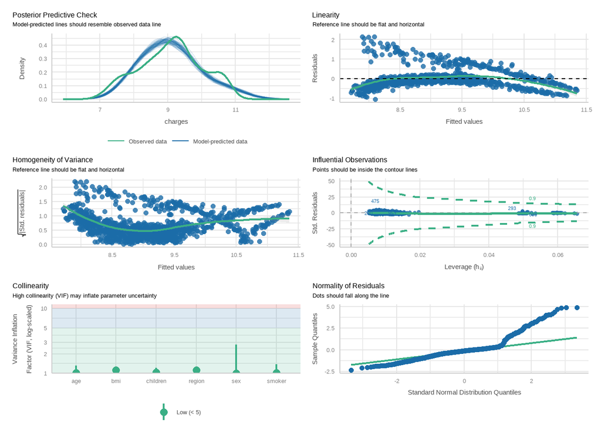

```r
m <- lm(charges ~ ., df_clean)

check_model(m)
```

### Normality Test

```r
normality(df_clean) %>%
  mutate(p_value = round(p_value, 6)) %>%
  flextable()
```

| vars | statistic | p_value | sample |
| --- | --- | --- | --- |
| age | 0.9423529 | 0.000000 | 1,243 |
| bmi | 0.9935677 | 0.000033 | 1,243 |
| charges | 0.9831001 | 0.000000 | 1,243 |

```r
check_normality(m)
```

[output not shown]

### Skewness

```r
df_clean %>%
  select_if(is.numeric) %>%
  lapply(agostino.test)
```

```
## $age
##
##  D'Agostino skewness test
##
## data:  X[[i]]
## skew = 0.063815, z = 0.923056, p-value = 0.356
## alternative hypothesis: data have a skewness
##
##
## $bmi
##
##  D'Agostino skewness test
##
## data:  X[[i]]
## skew = 0.2800, z = 3.9798, p-value = 6.896e-05
## alternative hypothesis: data have a skewness
##
##
## $charges
##
##  D'Agostino skewness test
##
## data:  X[[i]]
## skew = -0.088503, z = -1.278981, p-value = 0.2009
## alternative hypothesis: data have a skewness
```

### Heteroskedasticity test

```r
check_heteroskedasticity(m)
```

[output not shown]

### Collinearity test

```r
check_collinearity(m)
```

```
## # Check for Multicollinearity
##
## Low Correlation
##
##      Term  VIF   VIF 95% CI Increased SE Tolerance Tolerance 95% CI
##       age 1.02 [1.00, 1.31]         1.01      0.98     [0.76, 1.00]
##       sex 1.01 [1.00, 2.78]         1.01      0.99     [0.36, 1.00]
##       bmi 1.12 [1.07, 1.21]         1.06      0.89     [0.83, 0.94]
##  children 1.03 [1.00, 1.21]         1.01      0.97     [0.83, 1.00]
##    smoker 1.02 [1.00, 1.37]         1.01      0.98     [0.73, 1.00]
##    region 1.12 [1.07, 1.21]         1.06      0.89     [0.82, 0.94]
```

In the process of checking assumptions for multiple linear regression analysis, violations of both residual normality and variance homogeneity are observed. Consequently, the application of robust regression has become another chosen method in this scenario, apart from the OLS model.

## Correlation test

### `age` and `charges`

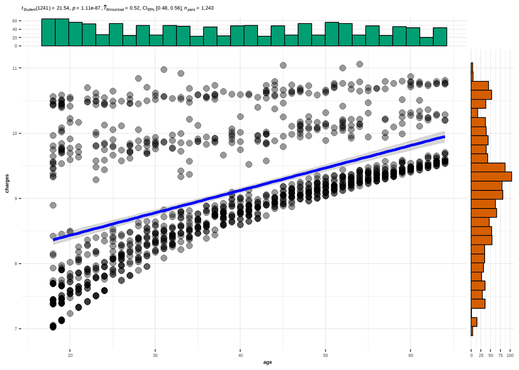

```r
ggscatterstats(
    data = df_clean,
    x    = age,
    y    = charges,
    type = "robust"
    )
```

```r
interpret_r(0.52)
```

```
## [1] "very large"
## (Rules: funder2019)
```

The correlation test results reveal a significant relationship between `charges` and `age`. The null hypothesis is rejected, as demonstrated by a p-value of 1.11e-87 and a confidence interval of [0.48, 0.56].

Furthermore, the correlation coefficient of 0.52 is classified as ‘very large’ following the guidelines of Funder & Ozer (2019), signifying a substantial effect size.

### `bmi` and `charges`

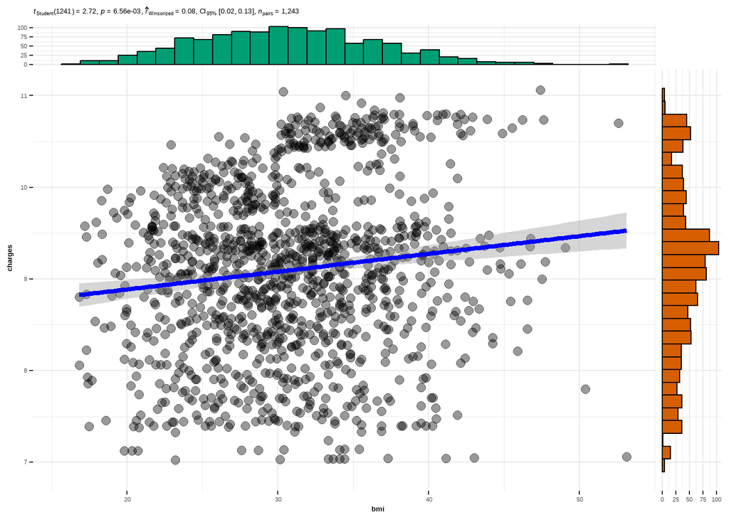

```r
ggscatterstats(
    data = df_clean,
    x    = bmi,
    y    = charges,
    type = "robust"
    )
```

```r
interpret_r(0.08)
```

```
## [1] "very small"
## (Rules: funder2019)
```

The correlation test results reveal a significant relationship between `charges` and `bmi`. The null hypothesis is rejected, as demonstrated by a p-value of 6.56e-03 and a confidence interval of [0.02, 0.13].

Furthermore, the correlation coefficient of 0.08 is classified as ‘very small’ following the guidelines of Funder & Ozer (2019), signifying a very small effect size.

## Model Selection and Evaluation

### Splitting Data into Training and Test Sets

```r
split_data <- function(data, size) {
  # Set the seed for random number generation
  set.seed(123)

  # Get the number of rows in the data
  n <- nrow(data)

  # Generate a random sample of row indices for the training data
  id <- sample(1:n, size = size * n)

  # Create the training data by selecting the rows with the sampled indices
  train_data <- data[id, ]

  # Create the test data by selecting the rows not in the training data
  test_data <- data[-id, ]

  # Return a list containing the training and test data
  list(train = train_data, test = test_data)
}
```

```r
splitData <- split_data(df_clean, 0.8)
train_data <- splitData$train
test_data <- splitData$test
```

### Automated Model Selection and Multimodel Inference with (G)LMs

```r
h_model <- glmulti(charges ~ .,
        data   = train_data,
        method = "h",       # Exhaustive approach
        crit   = aicc,      # AICC corrected AIC for small samples
        level  = 1,         # 2 with interactions, 1 without
        family = gaussian,
        plotty = FALSE,
        report = FALSE,
        fitfunction = glm,  # Type of model (LM, GLM, GLMER etc.)
        confsetsize = 100,)  # Keep 100 best models
```

```r
print(h_model)
```

```
## glmulti.analysis
## Method: h / Fitting: glm / IC used: aicc
## Level: 1 / Marginality: FALSE
## From 64 models:
## Best IC: 1267.9325577642
## Best model:
## [1] "charges ~ 1 + sex + children + smoker + region + age + bmi"
## Evidence weight: 0.785014677889407
## Worst IC: 2674.96196552021
## 1 models within 2 IC units.
## 1 models to reach 95% of evidence weight.
```

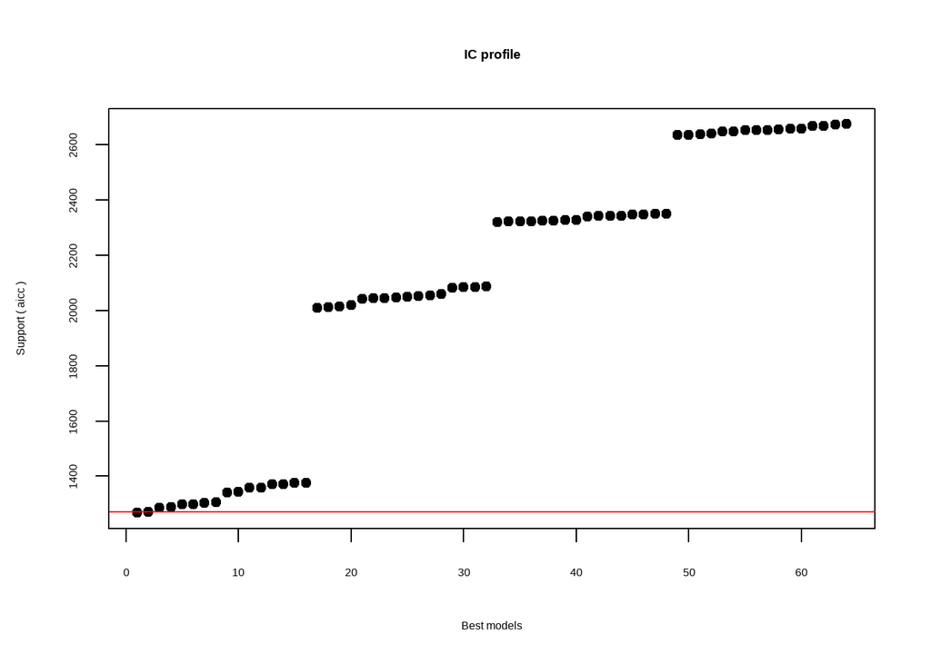

```r
plot(h_model)
```

```r
weightable(h_model)[1:10,] %>%
  regulartable() %>%       # beautifying tables
  autofit()
```

| model | aicc | weights |
| --- | --- | --- |
| charges ~ 1 + sex + children + smoker + region + age + bmi | 1,267.933 | 0.7850146778894073751331 |
| charges ~ 1 + children + smoker + region + age + bmi | 1,270.524 | 0.2148793341886895968962 |
| charges ~ 1 + sex + children + smoker + age + bmi | 1,286.313 | 0.0000801069016380493869 |
| charges ~ 1 + children + smoker + age + bmi | 1,288.607 | 0.0000254376039882645443 |
| charges ~ 1 + sex + children + smoker + region + age | 1,297.872 | 0.0000002475634596971655 |
| charges ~ 1 + children + smoker + region + age | 1,298.492 | 0.0000001815258123904688 |
| charges ~ 1 + sex + children + smoker + age | 1,304.619 | 0.0000000084806343934152 |
| charges ~ 1 + children + smoker + age | 1,305.363 | 0.0000000058463700051593 |
| charges ~ 1 + sex + smoker + region + age + bmi | 1,340.862 | 0.0000000000000001143986 |
| charges ~ 1 + smoker + region + age + bmi | 1,342.361 | 0.0000000000000000540776 |

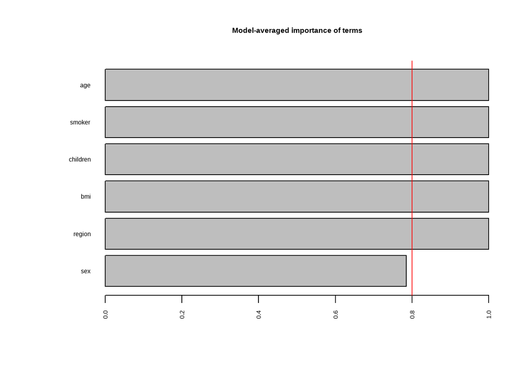

```r
plot(h_model, type = "s")
```

The glmulti package is used to perform an exhaustive search for the best general linear model predicting medical charges based on the variables in the dataset. The AICC information criterion is used for model selection, with lower values indicating a better model fit after adjusting for model complexity.

### Training Linear Regression Model

```r
set.seed(42)

ctrl <- trainControl(method = "repeatedcv",
                     number = 10,
                     repeats = 10,
                     verboseIter = FALSE)

lm_model <- train(charges ~ .,
                  data = train_data,
                  method = "lm",
                  metric = "RMSE",
                  preProcess = c("scale", "center"),
                  trControl = ctrl)
```

The code executes a linear regression model fitting on the `train_data` dataset. Initially, a random seed is established at 42 to ensure reproducibility. Subsequently, a cross-validation control object is configured with 10 folds and repeated 10 times, opting for non-verbose iteration. In the final step, the `lm` method from the `caret` package is employed to train a linear regression model. The model utilizes the `train_data` dataset to predict `charges` based on all other variables in the dataset. The Root Mean Square Error (RMSE) serves as the metric for evaluating the performance of the model. The data is preprocessed by scaling and centering before training.

### Evaluating Training Model

```r
rmse_lm_train <- lm_model$results$RMSE
rmse_lm_train
```

```
## [1] 0.4552644
```

The Root Mean Square Error (RMSE) of the linear regression model on the training data is 0.4552644. This value is on a log scale as the dependent variable `charges` was log-transformed. This means that the model’s predictions are, on average, approximately 0.46 units away from the actual values on the log scale. This provides a measure of the model’s performance and its ability to accurately predict `charges` based on the other variables in the `train_data` dataset.

### Summary of the Model

```r
summary(lm_model$finalModel)
```

```
##
## Call:
## lm(formula = .outcome ~ ., data = dat)
##
## Residuals:
##      Min       1Q   Median       3Q      Max
## -1.07234 -0.21873 -0.06392  0.07667  2.15821
##
## Coefficients:
##                 Estimate Std. Error t value Pr(>|t|)
## (Intercept)      9.10968    0.01441 632.114  < 2e-16 ***
## age              0.48079    0.01456  33.027  < 2e-16 ***
## sexmale         -0.03123    0.01456  -2.144 0.032240 *
## bmi              0.08646    0.01526   5.665 1.93e-08 ***
## children1        0.06474    0.01572   4.118 4.15e-05 ***
## children2        0.10249    0.01563   6.555 8.97e-11 ***
## children3        0.08271    0.01538   5.377 9.44e-08 ***
## children4        0.07730    0.01463   5.282 1.57e-07 ***
## children5        0.05718    0.01465   3.903 0.000102 ***
## smokeryes        0.62954    0.01459  43.150  < 2e-16 ***
## regionnorthwest -0.02690    0.01826  -1.473 0.140993
## regionsoutheast -0.08796    0.01908  -4.611 4.54e-06 ***
## regionsouthwest -0.06010    0.01822  -3.299 0.001007 **
## ---
## Signif. codes:  0 '***' 0.001 '**' 0.01 '*' 0.05 '.' 0.1 ' ' 1
##
## Residual standard error: 0.4544 on 981 degrees of freedom
## Multiple R-squared:  0.7614, Adjusted R-squared:  0.7585
## F-statistic: 260.9 on 12 and 981 DF,  p-value: < 2.2e-16
```

### Converting Log-Scaled Coefficients to Original Scale

```r
coefToScale <- function(model, coefs) {

  # Initialize final_coefs
  final_coefs <- numeric(length(coefs))

  # Apply (exp(coefs) - 1) only for the intercept
  final_coefs[1] <- exp(coefs[1]) - 1

  # Apply (exp(coefs) - 1) * 100 for the rest
  final_coefs[-1] <- (exp(coefs[-1]) - 1) * 100

  # Assign names to the final_coefs vector
  names(final_coefs) <- names(coefs)

  return(final_coefs)
}
```

```r
coefs <- coef(lm_model$finalModel)

coefToScale(lm_model,coefs )
```

```
##     (Intercept)             age         sexmale             bmi       children1
##     9041.363509       61.735835       -3.074845        9.030395        6.688067
##       children2       children3       children4       children5       smokeryes
##       10.792298        8.622529        8.036621        5.884320       87.674279
## regionnorthwest regionsoutheast regionsouthwest
##       -2.653860       -8.420503       -5.832689
```

### Generating Predictions for Testing Model

```r
lm_pred <- predict(lm_model, newdata = test_data)
```

### Evaluating Testing Model

```r
rmse_lm_test <- RMSE(lm_pred,test_data$charges)
rmse_lm_test
```

```
## [1] 0.4162629
```

The Root Mean Square Error (RMSE) of the linear regression model on the test data is 0.4162629. This value is also on a log scale, similar to the training data. The RMSE value indicates that the model’s predictions are, on average, approximately 0.42 units away from the actual values on the log scale when applied to the test data.

Comparing this with the RMSE of the training data (0.4552644), it can be observed that the model performs slightly better on the test data. This suggests that the model generalizes well and is not overfitting to the training data.

### Training Robust Linear Regression Model

```r
set.seed(42)

rlm_model <- train(charges ~ .,
                  data = train_data,
                  method = "rlm",
                  metric = "RMSE",
                  preProcess = c("scale", "center"),
                  trControl = ctrl)
```

The code executes a robust linear regression model fitting on the `train_data` dataset. Initially, a random seed is established at 42 to ensure reproducibility. Subsequently, a cross-validation control object `ctrl` is used, which was configured with 10 folds and repeated 10 times for non-verbose iteration in the previous `lm_model`. In the final step, the `rlm` method from the `caret` package is employed to train a robust linear regression model. The model utilizes the `train_data` dataset to predict `charges` based on all other variables in the dataset. The Root Mean Square Error (RMSE) serves as the metric for evaluating the performance of the model. The data is preprocessed by scaling and centering before training.

### Evaluating Training Model

```r
rmse_rlm_train <- min(rlm_model$results$RMSE)
rmse_rlm_train
```

```
## [1] 0.4701139
```

The Root Mean Square Error (RMSE) of the robust linear regression model on the training data is 0.4701139. This value is on a log scale as the dependent variable `charges` was log-transformed. This means that the model’s predictions are, on average, approximately 0.47 units away from the actual values on the log scale. This provides a measure of the model’s performance and its ability to accurately predict `charges` based on the other variables in the `train_data` dataset.

### Summary of the Model

```r
summary(rlm_model$finalModel)
```

```
##
## Call: rlm(formula = .outcome ~ ., data = dat, psi = psi)
## Residuals:
##       Min        1Q    Median        3Q       Max
## -0.966503 -0.093292  0.007193  0.081139  2.359526
##
## Coefficients:
##                 Value     Std. Error t value
## (Intercept)        9.0278    0.0055  1636.0957
## age                0.5687    0.0056   102.0257
## sexmale           -0.0365    0.0056    -6.5403
## bmi                0.0347    0.0058     5.9325
## children1          0.0623    0.0060    10.3458
## children2          0.0944    0.0060    15.7682
## children3          0.1002    0.0059    17.0087
## children4          0.0655    0.0056    11.6854
## children5          0.0667    0.0056    11.8931
## smokeryes          0.6407    0.0056   114.7053
## regionnorthwest   -0.0198    0.0070    -2.8324
## regionsoutheast   -0.0601    0.0073    -8.2251
## regionsouthwest   -0.0411    0.0070    -5.8970
##
## Residual standard error: 0.1271 on 981 degrees of freedom
```

### Converting Log-Scaled Coefficients to Original Scale

```r
coefToScale <- function(model, coefs) {

  # Initialize final_coefs
  final_coefs <- numeric(length(coefs))

  # Apply (exp(coefs) - 1) only for the intercept
  final_coefs[1] <- exp(coefs[1]) - 1

  # Apply (exp(coefs) - 1) * 100 for the rest
  final_coefs[-1] <- (exp(coefs[-1]) - 1) * 100

  # Assign names to the final_coefs vector
  names(final_coefs) <- names(coefs)

  return(final_coefs)
}
```

```r
coefs <- coef(rlm_model$finalModel)

coefToScale(rlm_model,coefs )
```

```
##     (Intercept)             age         sexmale             bmi       children1
##     8330.182304       76.590893       -3.581239        3.527335        6.425985
##       children2       children3       children4       children5       smokeryes
##        9.898956       10.535074        6.766742        6.898526       89.790269
## regionnorthwest regionsoutheast regionsouthwest
##       -1.960372       -5.830707       -4.030102
```

### Generating Predictions for Testing Model

```r
rlm_pred <- predict(rlm_model, newdata = test_data)
```

### Evaluating Testing Model

```r
rmse_rlm_test <- RMSE(rlm_pred,test_data$charges)
rmse_rlm_test
```

```
## [1] 0.4170331
```

The Root Mean Square Error (RMSE) of the robust linear regression model on the test data is 0.4170331. This value is also on a log scale, similar to the training data. The RMSE value indicates that the model’s predictions are, on average, approximately 0.42 units away from the actual values on the log scale when applied to the test data.

Comparing this with the RMSE of the training data (0.4701139), it can be observed that the model performs slightly better on the test data. This suggests that the model generalizes well and is not overfitting to the training data.

### Comparing Models’ Performance

```r
list_models <- list(lm = lm_model,
                    robust_lm = rlm_model)

result <- resamples(list_models)

summary(result)
```

```
##
## Call:
## summary.resamples(object = result)
##
## Models: lm, robust_lm
## Number of resamples: 100
##
## MAE
##                Min.   1st Qu.    Median      Mean   3rd Qu.      Max. NA's
## lm        0.2295001 0.2785587 0.2993325 0.2958849 0.3133347 0.3446020    0
## robust_lm 0.1807072 0.2401183 0.2632059 0.2609126 0.2825403 0.3280512    0
##
## RMSE
##                Min.   1st Qu.    Median      Mean   3rd Qu.      Max. NA's
## lm        0.3290813 0.4271797 0.4521967 0.4552644 0.4889363 0.5449069    0
## robust_lm 0.3040506 0.4342570 0.4685567 0.4701139 0.5092037 0.5906116    0
##
## Rsquared
##                Min.   1st Qu.    Median      Mean   3rd Qu.      Max. NA's
## lm        0.6361129 0.7218909 0.7669317 0.7578932 0.7998132 0.8969778    0
## robust_lm 0.6249309 0.7153031 0.7608445 0.7537371 0.7963130 0.9018183    0
```

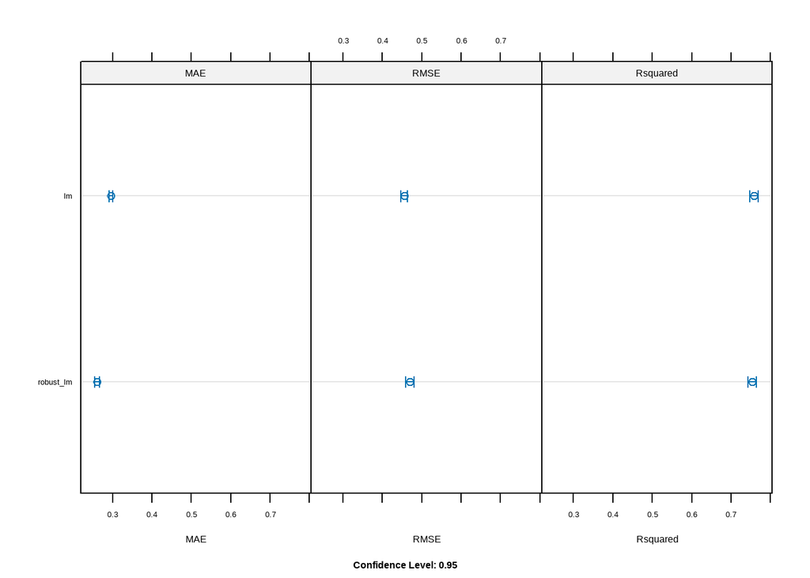

```r
dotplot(result)
```

### Visualizing the Correlation and Pairwise Relationships between Multiple Models

```r
modelCor(result)
```

```
##                 lm robust_lm
## lm        1.000000  0.934669
## robust_lm 0.934669  1.000000
```

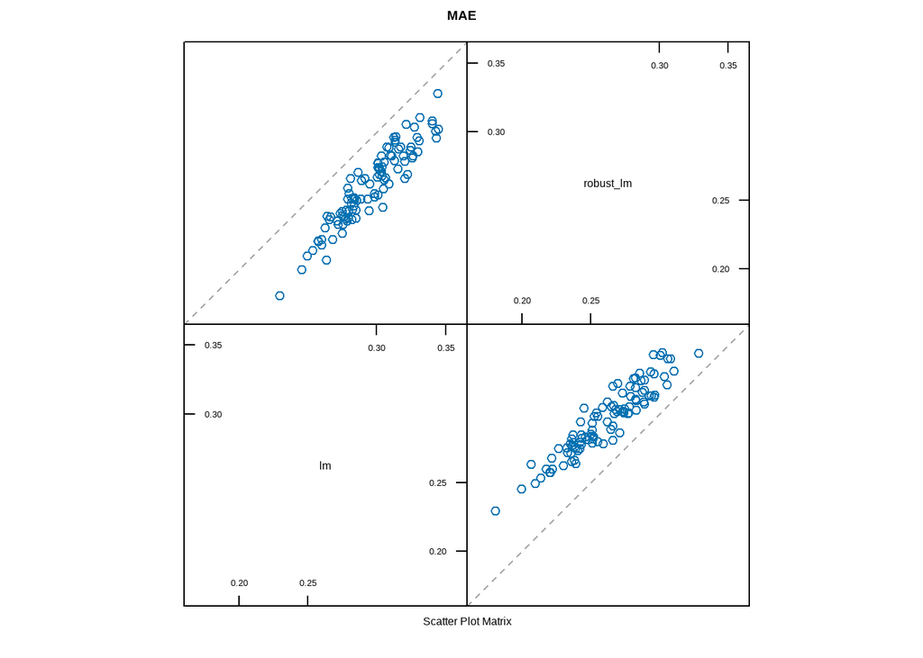

```r
splom(result)
```

```r
# Create a vector for each model
lm <- c(RMSE_train = rmse_lm_train, RMSE_test = rmse_lm_test)
rlm <- c(RMSE_train = rmse_rlm_train, RMSE_test = rmse_rlm_test)

# Combine the vectors into a dataframe
rmse_df <- rbind(lm, rlm)

# Name the rows
rownames(rmse_df) <- c("Linear Regression", "Robust Regression")

# Print the dataframe
print(rmse_df)
```

```
##                   RMSE_train RMSE_test
## Linear Regression  0.4552644 0.4162629
## Robust Regression  0.4701139 0.4170331
```

The analysis reveals comparable performance between the linear model (lm) and the robust linear model in terms of Root Mean Square Error (RMSE).

Moreover, a high correlation (approximately 0.935) exists between the two models, indicating highly correlated but not identical predictions.

In conclusion, both models demonstrate comparable performance in this analysis. The choice between them depends on other considerations such as interpretability or computational efficiency.

Given the slightly lower RMSE of the Linear Regression model on both training and test datasets, it appears to be slightly more accurate in its predictions.

However, considering the presence of outliers and violations of the assumptions of multiple linear regression in the data, the robust linear model (rlm) emerges as a better choice for this data. The rlm model is designed to be more resistant to outliers and violations of assumptions than the standard linear model (lm). Despite a slightly higher RMSE in this analysis, the rlm model’s resistance to outliers potentially makes it more reliable and accurate when predicting new data that may also contain outliers.

### Performing Robust Linear Regression Model in Original Unit

```r
rlm_train_pred <- predict(rlm_model, train_data)
```

```r
train_orig <- train_data

train_orig$pred_log_charges <- rlm_train_pred

train_orig$pred_charges <- exp(train_orig$pred_log_charges) - 1

train_orig$charges <- exp(train_orig$charges) - 1
```

```r
RMSE(train_orig$pred_charges, train_orig$charges)
```

```
## [1] 9372.574
```

```r
test_orig <- test_data

test_orig$pred_log_charges <- rlm_pred

test_orig$pred_charges <- exp(test_orig$pred_log_charges) - 1

test_orig$charges <- exp(test_orig$charges) - 1
```

```r
RMSE(test_orig$pred_charges, test_orig$charges)
```

```
## [1] 8563.942
```

The Root Mean Square Error (RMSE) values of 9372.574 for the training data and 8563.942 for the test data represent the average difference in dollars between the predicted and actual charges in terms of its original unit.

The lower RMSE value for the test data suggests that the model’s predictions are slightly more accurate on unseen data compared to the training data. However, considering the high RMSE values, there is considerable room for improving the model’s predictive accuracy.

The robust linear regression model, despite its slightly higher RMSE values compared to a standard linear regression model, may still be a better choice if the data contains outliers or violates assumptions of multiple linear regression. This is because it is designed to be more resistant to such issues.

# Conclusion and Recommendation

The analysis shows that the linear regression model and robust linear regression model have comparable performance in predicting healthcare charges, with close Root Mean Square Error (RMSE) values. However, the robust model is likely preferable given the presence of outliers and violations of assumptions in the data. Its resistance to outliers can make it more reliable for future unseen data.

The lower RMSE for test data suggests the model is slightly more accurate in predicting new data versus training data. But high overall RMSE indicates room for improvement in predictive accuracy.

Considering factors like interpretability, computational efficiency, and resistance to outliers, the robust linear regression model is recommended over the standard linear model. Despite a slightly higher RMSE, it is more resistant to issues like outliers that violate assumptions.

To reduce healthcare costs based on model coefficients, it is recommended to:

- Focusing on reducing smoking rates, as smoking has a very strong association with higher charges. Smoking cessation programs could provide significant savings.
- Encouraging maintenance of healthy BMI levels, as increased BMI is tied to higher costs. Lifestyle or dietary changes helping patients achieve a healthy BMI may help control rising expenses.
- Improving access to family planning resources, as having more children is linked to increased costs. Enabling better family planning could potentially reduce expenditures.
- Analyzing regional differences, specifically higher average costs in the Northeast, to uncover opportunities to reduce spending.

Overall, targeting modifiable health risks like smoking and obesity through public health efforts to promote healthy lifestyles could help curb rising healthcare costs.